# ESM 211 - Homework 1

Laura Ingulsrud

January 17, 2020

#### 1. Give three reasons why a plant or animal might be patchily distributed like this. For each, describe whether you would expect the location of the high-density patches to be consistent from year to year.

1. The high-density patches could be in areas of suitable habitat. For an animal population, the high-density patches might be locations of abundant food or safety from predators. For a plant population, the high-density patches might be or areas of optimal soil nutrients, water, and sunlight. Depending on how suitable habitat patches increase, decrease, or move spatially, the species would be expected to follow this pattern.
2. For plants, it could be a plant species that spreads outward from itself, or drops its seeds straight to the ground, rather than its seeds being dispersed more widely. This type of plant species would remain in clusters. In this situation, the location of these patches would be expected to be consistent from year to year.
3. For animals, it could be an animal species that lives in groups, such as herds of elephants. For this situation, whether the location of these patches remains consistent from year to year depends on the reason for the animals groups’ locations. For example, if they are grouped in areas of high food availability, location constancy depends on whether those areas remain rich in food or not.

## Eureka dune grass

#### 2. Read in the data, and use a two-sample t-test (e.g., using t.test() in R) to assess whether and how mean abundance changed from 2009 to 2010. Choose a level for α, and justify your choice. On the basis of this analysis, what do you conclude about the change in the grass’s abundance?

```r
# Read in data for Eureka dune grass (Swallenia alexandrae) on Saline Dune
swallenia <- read.csv("Swallenia.csv")

# Use two-sample t-test to assess whether and how mean abundance changed from 2009 to 2010
swallenia_t <- t.test(swallenia$count_2009, swallenia$count_2010, var.equal = TRUE)

swallenia_t
```

```
##
##  Two Sample t-test
##
## data:  swallenia$count_2009 and swallenia$count_2010
## t = -0.81791, df = 20, p-value = 0.423
## alternative hypothesis: true difference in means is not equal to 0
## 95 percent confidence interval:
##  -140.07803   61.16893
## sample estimates:
## mean of x mean of y
##  61.90909 101.36364
```

```r
# Null hypothesis: true difference in means is equal to 0
# Alternative hypothesis: true difference in means is not equal to 0
# Since p > alpha (0.42 > 0.05), we retain the null hypothesis
```

A significance level of 0.05 was chosen for $\alpha$ because it indicates a 5% risk of concluding a difference in mean abundance exists, when there actually is no difference in mean abundance of Eureka dune grass between the two years. There is a 0.05 probability that a Type I error will be committed (the null hypothesis is true, and we reject it). Due to this low risk in committing a Type I error, a significance level of 0.05 is common in hypothesis testing, especially for a two-tailed t-test. It is also the default significance level used in the t.test function in R.

Eureka dune grass mean abundance on Saline Dune between 2009 and 2010 did not differ significantly (p = 0.42, $\alpha$ = 0.05).

#### 3. Because the plant was counted in the same plots each year, you can also do a paired t-test (R hint: use paired = TRUE in t.test()). On the basis of this analysis, what do you conclude about the change in the grass’s abundance?

```r
# Do a paired t-test
swallenia_tpaired <- t.test(swallenia$count_2009, swallenia$count_2010, paired = TRUE)

swallenia_tpaired
```

```
##
##  Paired t-test
##
## data:  swallenia$count_2009 and swallenia$count_2010
## t = -2.4508, df = 10, p-value = 0.03421
## alternative hypothesis: true difference in means is not equal to 0
## 95 percent confidence interval:
##  -75.324830  -3.584261
## sample estimates:
## mean of the differences
##               -39.45455
```

```r
# Null hypothesis: true difference in means is equal to 0
# Alternative hypothesis: true difference in means is not equal to 0
# Since p < alpha (0.03 < 0.05), we reject the null hypothesis
```

The true difference in means between Eureka dune grass abundance on Saline Dune between 2009 and 2010 is not equal to 0; therefore, the change in abundance between the two years differed significantly (p = 0.03, $\alpha$ = 0.05).

#### 4. Which of these analyses is more appropriate? Why? (Hint: think about your answers to question 1, and whether any apply here)

The paired t-test analysis is more appropriate because there is a one-to-one relationship between values in the two Eureka dune grass samples from 2009 and 2010. Since plants were counted in the same 11 quadrats across the dune, the counts were from the same locations each year data were collected. This makes sense since Eureka dune grass spreads outward from itself and likely exhibits clumped dispersion; therefore, the quadrats can be expected to capture any changes in plant abundance year to year.

### Yellowstone grizzly bears

#### 6. Open the file, and look at the data from 1959 to 1968. Did the grizzly bear population decline over this period? Support your conclusion with graphs, statistics, and logical reasoning.

```r
# Read in grizzly data
grizzlydata <- read.csv("grizzlydata.csv")

# Filter grizzly data to only include years 1959 - 1968
grizzly1959_1968 <- grizzlydata %>%
  filter(between(Year, 1959, 1968))

# Create exploratory scatterplot
gg_grizzly1959_1968 <- ggplot(grizzly1959_1968, aes(x = Year, y = N)) +
  geom_point()
# It looks like the trend is generally a negative linear relationship. However, it seems the population was relatively stable from 1959 to 1965, but it drastically declined after 1965. Overall though, it looks like a linear relationship between grizzly bear population and year makes sense.

# Run linear regression model to describe the trend in grizzly bear population from 1959 - 1968
grizzly1959_1968_lm <- lm(N ~ Year, data = grizzly1959_1968)
grizzly1959_1968_lm
```

```
##
## Call:
## lm(formula = N ~ Year, data = grizzly1959_1968)
##
## Coefficients:
## (Intercept)         Year
##   1543.0000      -0.7636
```

```r
# y = -0.7636x + 1543
# Grizzly population = -0.7636(Year) + 1543

# Explore model fit and significance
summary(grizzly1959_1968_lm)
```

```
##
## Call:
## lm(formula = N ~ Year, data = grizzly1959_1968)
##
## Residuals:
##     Min      1Q  Median      3Q     Max
## -3.0364 -1.5591 -0.1273  1.5182  3.5455
##
## Coefficients:
##              Estimate Std. Error t value Pr(>|t|)
## (Intercept) 1543.0000   472.9413   3.263   0.0115 *
## Year          -0.7636     0.2409  -3.170   0.0132 *
## ---
## Signif. codes:  0 '***' 0.001 '**' 0.01 '*' 0.05 '.' 0.1 ' ' 1
##
## Residual standard error: 2.188 on 8 degrees of freedom
## Multiple R-squared:  0.5568, Adjusted R-squared:  0.5014
## F-statistic: 10.05 on 1 and 8 DF,  p-value: 0.01319
```

```r
# Get model outputs in table form
grizzly1959_1968_lm_tidy <- broom::tidy(grizzly1959_1968_lm)

# Get the intercept:
grizzly1959_1968_int <- grizzly1959_1968_lm_tidy$estimate[1]
# 1543

# Get the Year coefficient:
grizzly1959_1968_coef <- grizzly1959_1968_lm_tidy$estimate[2]
# -0.7636

# Metrics at a glance:
grizzly1959_1968_lm_out <- broom::glance(grizzly1959_1968_lm)

# Check diagnostic plots
# plot(grizzly1959_1968_lm)
# Looks ok (commented out for Rmarkdown)

# Find Pearson's r for correlation:
grizzly1959_1968_cor <- cor.test(grizzly1959_1968$N, grizzly1959_1968$Year)
# r = -0.7462 (strong negative correlation)
# Correlation is significantly non-zero (p = 0.01 < 0.05)
```

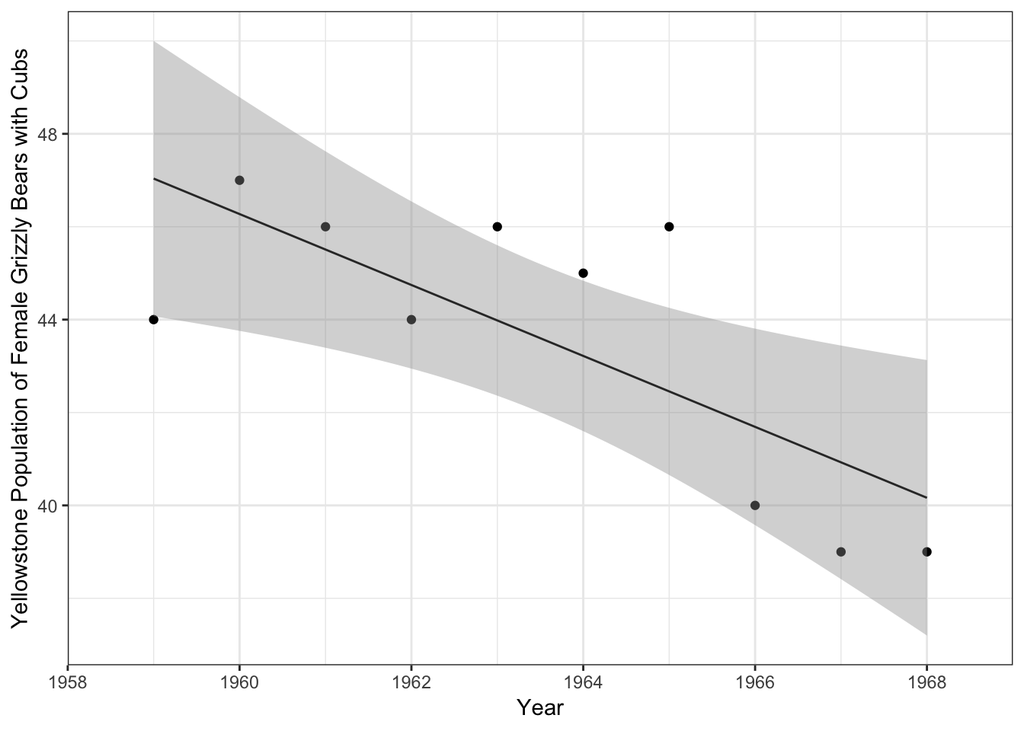

```r
# Prepare final graph of the linear regression model with the original data, model, and 95% confidence interval for predictions
grizzly1959_1968_graph <- ggplot(grizzly1959_1968, aes(x = Year, y = N)) +
  geom_point() +
  geom_smooth(method = lm, se = TRUE, size = 0.5, color = "gray20") +
  theme_bw() +
  scale_x_continuous(expand = c(0,0), limits = c(1958, 1969)) +
  labs(x = "Year", y = "Yellowstone Population of Female Grizzly Bears with Cubs")

grizzly1959_1968_graph
```

Simple linear regression was used to explore the relationship between grizzly bear population (number of adult females with cubs) and time (years) between 1959 and 1968.

The equation for the linear regression model is *Grizzly Bear Population = -0.7636(Year) + 1543*.

There is a strong negative correlation between grizzly bear population and year (*r* = -0.75, t(8) = -3.17, p = 0.01, $\alpha$ = 0.05).

The linear regression model shows that the grizzly bear population declined at a statistically significant rate of -0.7636 bears per year from 1959 to 1968 ($\sigma$ = 2.19, p = 0.01, $\alpha$ = 0.05).

#### 7. Select the data from 1969 to 1978. Did the population continue to decline? Was the decline faster than the period prior to the dump closures?

```r
# Filter grizzly data to only include years 1969 - 1978
grizzly1969_1978 <- grizzlydata %>%
  filter(between(Year, 1969, 1978))

# Create exploratory scatterplot
gg_grizzly1969_1978 <- ggplot(grizzly1969_1978, aes(x = Year, y = N)) +
  geom_point()
# Overall, it looks like the trend is generally a negative linear relationship. However, there are some outliers on both ends.

# Perform linear regression to describe the trend in grizzly bear population from 1959 - 1968
grizzly1969_1978_lm <- lm(N ~ Year, data = grizzly1969_1978)

grizzly1969_1978_lm
```

```
##
## Call:
## lm(formula = N ~ Year, data = grizzly1969_1978)
##
## Coefficients:
## (Intercept)         Year
##   1532.3758      -0.7576
```

```r
# Grizzly population = -0.7576(Year) + 1532.38

# Explore model fit and signifiance
summary(grizzly1969_1978_lm)
```

```
##
## Call:
## lm(formula = N ~ Year, data = grizzly1969_1978)
##
## Residuals:
##     Min      1Q  Median      3Q     Max
## -4.6788 -0.9439  0.2303  1.4955  3.5939
##
## Coefficients:
##              Estimate Std. Error t value Pr(>|t|)
## (Intercept) 1532.3758   536.3641   2.857   0.0213 *
## Year          -0.7576     0.2718  -2.787   0.0237 *
## ---
## Signif. codes:  0 '***' 0.001 '**' 0.01 '*' 0.05 '.' 0.1 ' ' 1
##
## Residual standard error: 2.469 on 8 degrees of freedom
## Multiple R-squared:  0.4927, Adjusted R-squared:  0.4293
## F-statistic:  7.77 on 1 and 8 DF,  p-value: 0.02365
```

```r
# Get model outputs in table form
grizzly1969_1978_lm_tidy <- broom::tidy(grizzly1969_1978_lm)

# Get the intercept:
grizzly1969_1978_int <- grizzly1969_1978_lm_tidy$estimate[1]
# 1532.376

# Get the Year coefficient:
grizzly1969_1978_coef <- grizzly1969_1978_lm_tidy$estimate[2]
# -0.7575758

# Metrics at a glance:
grizzly1969_1978_lm_out <- broom::glance(grizzly1969_1978_lm)

# Check diagnostic plots
# plot(grizzly1969_1978_lm)
# Looks ok (commented out for RMarkdown)

# Find Pearson's r for correlation:
grizzly1969_1978_cor <- cor.test(grizzly1969_1978$N, grizzly1969_1978$Year)
# r = -0.701926 (strong negative correlation)
# Correlation is significantly non-zero (p = 0.02 < 0.05)
```

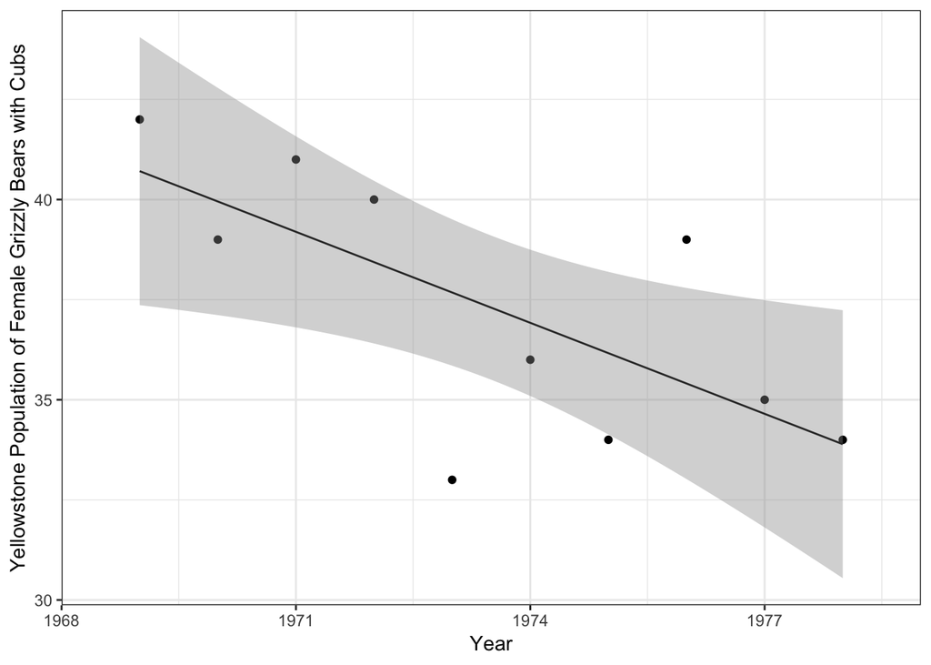

```r
# Prepare final graph of the linear regression model with the original data, model, and 95% confidence interval for predictions
grizzly1969_1978_graph <- ggplot(grizzly1969_1978, aes(x = Year, y = N)) +
  geom_point() +
  geom_smooth(method = lm, se = TRUE, size = 0.5, color = "gray20") +
  theme_bw() +
  scale_x_continuous(expand = c(0,0), limits = c(1968, 1979)) +
  labs(x = "Year", y = "Yellowstone Population of Female Grizzly Bears with Cubs")

grizzly1969_1978_graph
```

Simple linear regression was used to explore the relationship between grizzly bear population (number of adult females with cubs) and time (years) between 1969 and 1978.

The equation for the linear regression model is: *Grizzly Bear Population = -0.7576(Year) + 1532*.

The linear regression model shows that the grizzly bear population continued to decline at a statistically significant rate of -0.7576 bears per year from 1969 to 1978 ($\sigma$ = 2.47, p = 0.02, $\alpha$ = 0.05). The rate of decline (-0.7576 bears per year) was slightly slower than the period prior to the dump closures (-0.7636 bears per year).

#### 8. Finally look at the data after 1978. Did population size continue to change? What was the direction and magnitude of the trend?

```r
# Filter grizzly data to only include years 1978 - 1997
grizzly1978_1997 <- grizzlydata %>%
  filter(between(Year, 1978, 1997))

# Create exploratory scatterplot
gg_grizzly1978_1997 <- ggplot(grizzly1978_1997, aes(x = Year, y = N)) +
  geom_point()
# Overall, it looks like the trend is generally a positive linear relationship.

# Perform linear regression to describe the trend in grizzly bear population from 1959 - 1968
grizzly1978_1997_lm <- lm(N ~ Year, data = grizzly1978_1997)

grizzly1978_1997_lm
```

```
##
## Call:
## lm(formula = N ~ Year, data = grizzly1978_1997)
##
## Coefficients:
## (Intercept)         Year
##    -6043.13         3.07
```

```r
# Grizzly population = 3.07(Year) - 6043.13

# Explore model fit and significance
summary(grizzly1978_1997_lm)
```

```
##
## Call:
## lm(formula = N ~ Year, data = grizzly1978_1997)
##
## Residuals:
##      Min       1Q   Median       3Q      Max
## -18.2346  -4.1402   0.0102   3.7496  14.5556
##
## Coefficients:
##               Estimate Std. Error t value Pr(>|t|)
## (Intercept) -6043.1256   593.4783  -10.18 6.76e-09 ***
## Year            3.0699     0.2986   10.28 5.82e-09 ***
## ---
## Signif. codes:  0 '***' 0.001 '**' 0.01 '*' 0.05 '.' 0.1 ' ' 1
##
## Residual standard error: 7.7 on 18 degrees of freedom
## Multiple R-squared:  0.8545, Adjusted R-squared:  0.8464
## F-statistic: 105.7 on 1 and 18 DF,  p-value: 5.821e-09
```

```r
# Get model outputs in table form
grizzly1978_1997_lm_tidy <- broom::tidy(grizzly1978_1997_lm)

# Get the intercept:
grizzly1978_1997_int <- grizzly1978_1997_lm_tidy$estimate[1]
# -6043.126

# Get the Year coefficient:
grizzly1978_1997_coef <- grizzly1978_1997_lm_tidy$estimate[2]
# 3.069925

# Metrics at a glance:
grizzly1978_1997_lm_out <- broom::glance(grizzly1978_1997_lm)

# Check diagnostic plots
# plot(grizzly1978_1997_lm)
# Looks good (commented out for RMarkdown)

# Find Pearson's r for correlation:
grizzly1978_1997_cor <- cor.test(grizzly1978_1997$N, grizzly1978_1997$Year)
# r = 0.9243827 (strong positive correlation)
# Correlation is significantly non-zero (p < 0.001 < 0.05)
```

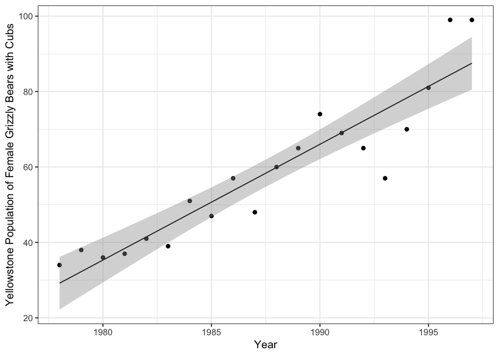

```r
# Prepare final graph of the linear regression model with the original data, model, and 95% confidence interval for predictions
grizzly1978_1997_graph <- ggplot(grizzly1978_1997, aes(x = Year, y = N)) +
  geom_point() +
  geom_smooth(method = lm, se = TRUE, size = 0.5, color = "gray20") +
  scale_x_continuous(expand = c(0,0), limits = c(1977, 1998)) +
  labs(x = "Year", y = "Yellowstone Population of Female Grizzly Bears with Cubs") +
  theme_bw()

grizzly1978_1997_graph
```

Simple linear regression was used to explore the relationship between grizzly bear population (number of adult females with cubs) and time (years) between 1978 and 1997.

The equation for the linear regression model is *Grizzly Bear Population = 3.07(Year) - 6043*.

There is also a strong positive correlation between grizzly bear population and year (*r* = 0.92, t(18) = 10.28, p < 0.001, $\alpha$ = 0.05).

The linear regression model shows that the grizzly bear population increased at a statistically significant rate of 3.07 bears per year from 1978 to 1997 ($\sigma$ = 7.7, p < 0.001, $\alpha$ = 0.05).

#### 9. Write a short paragraph to the park superintendent describing your conclusions on the effects (if any) of the dump closures on the grizzly bear population.

During the 10 years prior to the dump closures, the population of female grizzly bears with cubs in Yellowstone National Park was declining at a statistically significant rate. During the 10 years following the first dump closures in 1968, the grizzly bear population continued to significantly decline, although at a slightly slower rate than before the dump closures. However, after 1978, 10 years after dump closures were first implemented, the grizzly bear population has significantly increased. This indicates that the grizzly bear population’s declining trend was reversed by the dump closures, although it took around 10 years for the effects of the closures to be apparent. Closing the dumps could have had this positive impact on the grizzly bear population partly due to the subsequent reduction of human-bear interactions resulting in killing bears (Craighead and Craighead 1971). Further research is necessary to determine the causes of this population trend reversal, especially regarding bear fecundity rates before and after the dump closures (Stringham 1986).